# Practical Machine Learning Course Project Report

Paulo Oliveira

February 2016

### Abstract

This assignment is part of the *Practical Machine Learning* class project in the Coursera data Science Specialization. The goal of this project is to analyze an exercise measurements dataset, and then predict quality of exercise based on associated predictor variables. In this report, we first show how the data was loaded and cleaned-up (pre-processing). A prediction model was built on the *training* set and the performance estimated through cross-validation.

### Load and Pre-process the Data

We start by loading the training and testing datasets into dataframes:

```r
setwd("~/Data Science Specialization/Practical Machine Learning/Project")
# Many fields have no values or #DIV/0 wich we will consider to be NA strings:
training <- read.csv("pml-training.csv", na.strings = c("NA", "#DIV/0!"))
testing <- read.csv("pml-testing.csv" , na.strings = c("NA", "#DIV/0!"))
summary(training)
```

We now remove the ‘user_name’ and ‘X’ (row index) columns. These variables should not be used for a model intended to predict on any generic user.

```r
# remove:
# user_name - not a predictor we can generally use
# X - row index
training <- subset(training, select = -c(X, user_name))
testing <- subset(testing, select = -c(X, user_name))
```

There are also columns that contain time/window information which should not contribute to the prediction model as the authors state these are ‘sliding windows’ thus uncorrelated with the classe.

```r
# remove time/window columns before building model
training <- subset(training, select = -c(new_window, num_window, raw_timestamp_part_1, raw_timestamp_part_2, cvtd_timestamp))
testing <- subset(testing, select = -c(new_window, num_window, raw_timestamp_part_1, raw_timestamp_part_2, cvtd_timestamp))
```

By running summary() on the training dataset (result not listed here for brevity), we find that many of the columns (variables) contain very few values (mostly NAs). We therefore remove the columns where more than 90% of the values are missing:

```r
# Find columns with mostly NAs and remove them
trow = nrow(training)
colrm = apply(training, 2, function(x) sum(is.na(x))/trow > 0.9 )
training = subset(training, select = !colrm)
testing = subset(testing, select = !colrm)
```

This leaves us with 53 variables to use in our model which is a more manageable number.

### Create a Prediction Model

To determine what type of model to use, it is often useful to examine how the variables correlate with the outcome (‘classe’ in this case). If there are highly correlated variables with ‘classe’, then a linear model may be adequate. If not, then we choose a non-linear boosting or random forests algorithm instead.

```r
# calculate correlations
preds <- names(training)[-length(names(training))] # all but 'classe'
cor <- abs(sapply(preds, function(x) cor(as.numeric(training[, x]), as.numeric(training$classe))))
summary(cor)
```

```
##      Min.   1st Qu.    Median      Mean   3rd Qu.      Max.
## 0.0009977 0.0131000 0.0454000 0.0798400 0.1204000 0.3438000
```

We have not found any predictors that correlate with `classe` very strongly (maximum was 0.344), so a linear regression model is not likely to be a good choice here. We will try boosting and random forests instead.

#### Random Forest

We start by fitting a model with random forests algorithm and 10-fold cross validation to predict `classe` from all other predictors.

```r
set.seed(322)
mod_rf <- train(classe ~ ., method = "rf", data = training,
                 importance = T,
                trControl = trainControl(method = "cv", number = 10))
mod_rf
```

```
## Random Forest
##
## 19622 samples
##    52 predictor
##     5 classes: 'A', 'B', 'C', 'D', 'E'
##
## No pre-processing
## Resampling: Cross-Validated (10 fold)
## Summary of sample sizes: 17660, 17659, 17659, 17660, 17662, 17661, ...
## Resampling results across tuning parameters:
##
##   mtry  Accuracy   Kappa      Accuracy SD  Kappa SD
##    2    0.9949037  0.9935532  0.002135483  0.002701673
##   27    0.9944960  0.9930374  0.002036289  0.002576489
##   52    0.9897057  0.9869768  0.003871933  0.004899891
##
## Accuracy was used to select the optimal model using  the largest value.
## The final value used for the model was mtry = 2.
```

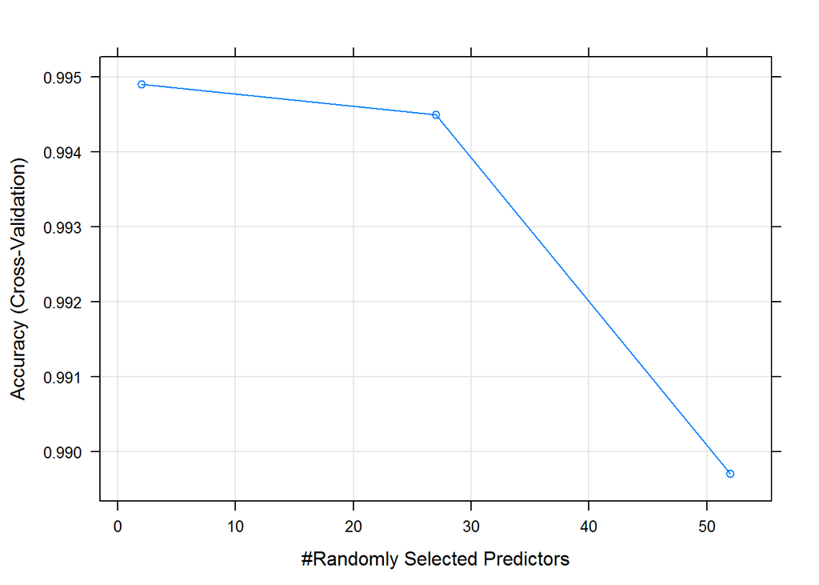

```r
plot(mod_rf)
```

The random forest model performed very well in-sample, with about 99.5% Accuracy.

#### Boosting

Similarly to what we did with random forests, we now fit a model using the boosting algorithm and 10-fold cross validation to predict `classe` from all other predictors.

```r
set.seed(322)
mod_boost <- train(classe ~ ., method = "gbm", data = training,
                    verbose = F,
                    trControl = trainControl(method = "cv", number = 10))
mod_boost
```

```
## Stochastic Gradient Boosting
##
## 19622 samples
##    52 predictor
##     5 classes: 'A', 'B', 'C', 'D', 'E'
##
## No pre-processing
## Resampling: Cross-Validated (10 fold)
## Summary of sample sizes: 17660, 17659, 17659, 17660, 17662, 17661, ...
## Resampling results across tuning parameters:
##
##   interaction.depth  n.trees  Accuracy   Kappa      Accuracy SD
##   1                   50      0.7528298  0.6865600  0.012217195
##   1                  100      0.8221382  0.7748665  0.008845385
##   1                  150      0.8560283  0.8178147  0.006125331
##   2                   50      0.8555191  0.8169266  0.005940320
##   2                  100      0.9089290  0.8847418  0.005352693
##   2                  150      0.9332381  0.9155172  0.003322829
##   3                   50      0.8981244  0.8710365  0.005756629
##   3                  100      0.9451128  0.9305545  0.002209523
##   3                  150      0.9648857  0.9555774  0.003700454
##   Kappa SD
##   0.015604059
##   0.011151537
##   0.007713636
##   0.007511028
##   0.006748569
##   0.004211206
##   0.007293192
##   0.002791931
##   0.004682503
##
## Tuning parameter 'shrinkage' was held constant at a value of 0.1
##
## Tuning parameter 'n.minobsinnode' was held constant at a value of 10
## Accuracy was used to select the optimal model using  the largest value.
## The final values used for the model were n.trees = 150,
##  interaction.depth = 3, shrinkage = 0.1 and n.minobsinnode = 10.
```

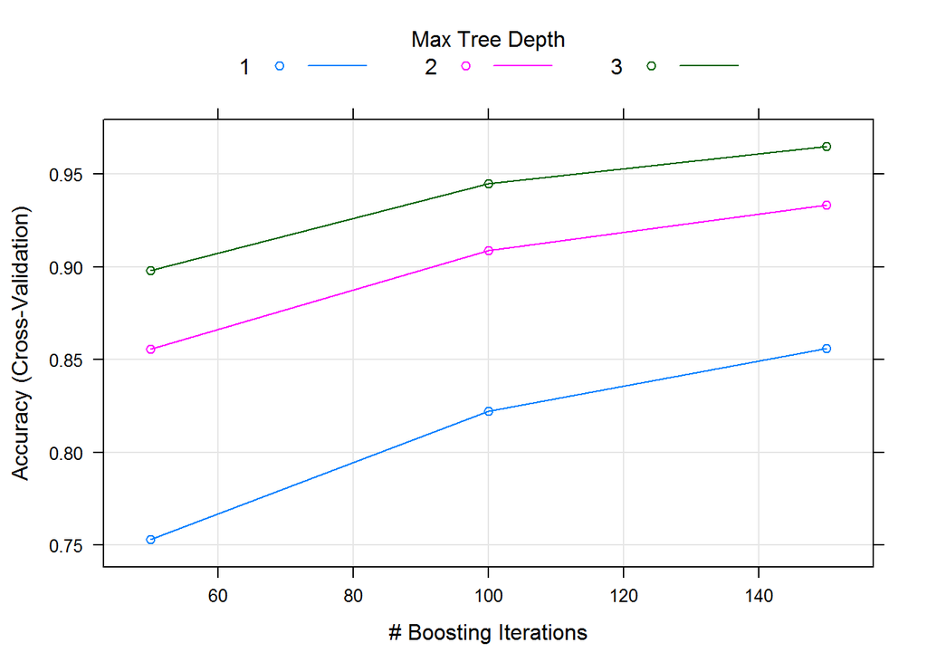

```r
plot(mod_boost)
```

The boosting model performs well with a 96.5% Accuracy in-sample, though not as well as the Random Forest model.

### Final model and prediction

If we had to choose a single model at this stage, we would go with the Random Forest model as it performed slightly better.

```r
mod_rf$finalModel
```

```
##
## Call:
##  randomForest(x = x, y = y, mtry = param$mtry, importance = ..1)
##                Type of random forest: classification
##                      Number of trees: 500
## No. of variables tried at each split: 2
##
##         OOB estimate of  error rate: 0.43%
## Confusion matrix:
##      A    B    C    D    E  class.error
## A 5578    1    0    0    1 0.0003584229
## B   12 3780    5    0    0 0.0044772189
## C    0   15 3403    4    0 0.0055523086
## D    0    0   40 3175    1 0.0127487562
## E    0    0    1    5 3601 0.0016634322
```

The OOB (out of bag), out of sample error estimate for mod_rf (from cross-validation) is only 0.43% which is very good.

Finally, we can now look at the predictions in the testing dataset. In this case, both models yield the same predictions:

```r
predict(mod_rf, testing)
```

```
##  [1] B A B A A E D B A A B C B A E E A B B B
## Levels: A B C D E
```

```r
predict(mod_boost, testing)
```

```
##  [1] B A B A A E D B A A B C B A E E A B B B
## Levels: A B C D E
```

We will use these predictions to submit to the project quiz.

#### Platform Information

- R version 3.2.3 (2015-12-10). nickname ‘Wooden Christmas-Tree’
- Platform: x86_64-w64-mingw32/x64 (64-bit)